# GroupTrack — User Manual

**Check in**

What is it?

Checking in puts you on a ride: which ride, the callsign you ride under, and your role — and it sets your radio up for the ride's network, so you hear the group and the group sees you.

How do I use it?

At the trailhead, radio on and connected, tap **✔ CHK IN**:

1. **Which ride?** Tap the ride (All, or one organizer's rides). A ride dated today is already chosen. Not on a planned ride? Tap **No scheduled ride** — a normal recording: no survey and no sharing; you name the track at the end.
2. **Callsign for this ride** — yours to start with; change it for this ride only (a shared cart, a guest driver).
3. **Role** — Leader, Rider, Middle or Tail gunner. If someone already holds the role, GroupTrack says who; choose another.
4. Tap **CHECK IN**. If your radio is not set for the ride yet, it is set up first (about a minute, with its progress on screen).

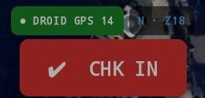

Before: ✔ CHK IN

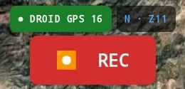

Checked in: ⏺ REC — tap it when the group rolls out

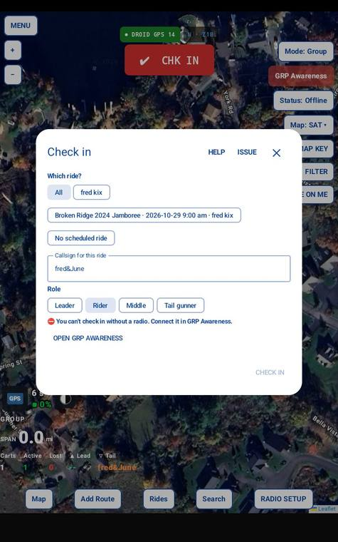

Check-in group aware

**Check in.** Choose the ride (or **No scheduled ride**), check your callsign, tap your role, then **CHECK IN**.

No radio connected? The red line says so: tap **OPEN GRP AWARENESS** and connect it first.

Checked in, the button reads **⏺ REC** (above) — checking in does not start recording — and the map shows the ride's route and waypoints.

What does it mean to me?

One step puts you on the ride and tells the group you are there — with your role on everyone's map.

**More: Checking in, step by step**

**Everybody checks in first thing at the trailhead.** Radio on, GroupTrack started, check in. Checking in is what puts your radio on the ride's network — until then it cannot hear the group. The Leader, Middle and Tail gunner check in among the first, so the whole group learns their roles.

- **Which ride?** Every ride on your tablet, newest first, opened at today. If exactly one is dated today, it is already chosen. Pick **No scheduled ride** for a recording that is not part of a ride — your radio goes back to the GroupTrack default network (tick **Keep my radio as it is** to leave it alone).
- **Callsign for this ride** — yours to start with; change it for this ride only (a shared cart, a guest driver).
- **Role** — Leader, Rider, Middle or Tail gunner. There is one of each of the first three: if another rider already holds the role you choose, GroupTrack says who, and you choose another.
- **Your radio** — GroupTrack compares it with the ride: "Radio ready for this ride", or it is set up when you check in (about a minute, with its progress on screen). If it cannot finish, the check-in reopens with your choices kept.

Carried from the 2.7b manual — check the wording.

**The readout after check-in**

What is it?

Once you check in, the readout at the bottom left shows the group, and **Add Route** on the bottom bar becomes **View: Group / View: My Cart**.

How do I use it?

- **View: Group** — the readout shows the group: span (lead to tail), carts, active, lost, the lead and the tail.
- **View: My Cart** — your own cart: heading, battery, altitude, speed, and the distance to the lead and the tail.
- **Tap a cart on the map** to see that cart's readout; View: My Cart or View: Group brings you back.

[figure not shown]

After check-in routes becomes my cart or group cart check-in becomes record

**After check-in** the bottom bar's Add Route becomes **View: My Cart / View: Group**: tap it to switch the readout at the bottom left between your cart and the whole group.

What does it mean to me?

At a glance you know where the group is and how strung out it is.

**Recording**

What is it?

Recording writes your track — where you went — as you ride.

How do I use it?

- Tap **⏺ REC** to start. The button becomes **⏸ PAUSE**, CENTRE ON ME becomes **FOLLOWING ME**, and the distance recorded shows in red at the bottom right.
- Stopping for a break? Tap **⏸ PAUSE**, then **RESUME** to carry on the same track.
- Finished? From PAUSE, tap **END** (see Ending the ride).

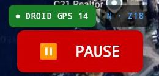

Recording: ⏸ PAUSE

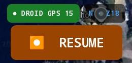

Paused: RESUME

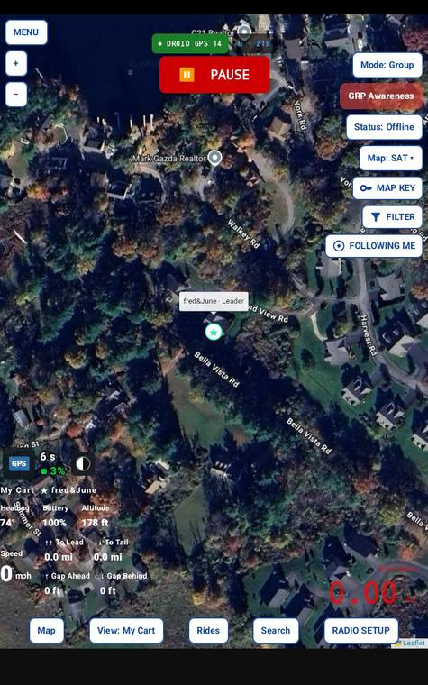

Record running

**Recording.** The button reads **⏸ PAUSE**, CENTRE ON ME reads **FOLLOWING ME**, and the distance recorded shows in red at the bottom right.

Stopping for a break? Tap **⏸ PAUSE**; it becomes **RESUME** (above) — tap it to carry on the same track.

What does it mean to me?

Every ride is recorded as a track you can follow again, turn into a route, or share.

**Ending the ride**

What is it?

Ending the ride saves your track — named after the ride — and, on a public ride, asks how it was.

How do I use it?

Tap **⏸ PAUSE**, then **END**. **Save your ride** opens:

- **A scheduled ride:** the track name is the ride's name. Rate it (stars), choose the difficulty (Easy, Moderate, Hard), would you recommend it (Yes / No), notes if you like, and **Share this ride's track with the community?** — Yes, share it / No, keep it. SAVE is ready once those are chosen (the line above SAVE says what is missing).
- **No scheduled ride:** just name the track and SAVE.

**DELETE** throws the recording away (it asks first). After saving, the button reads ✔ CHK IN again.

[figure not shown]

Pause end

**Finished?** Tap **⏸ PAUSE**; under it, tap **END**.

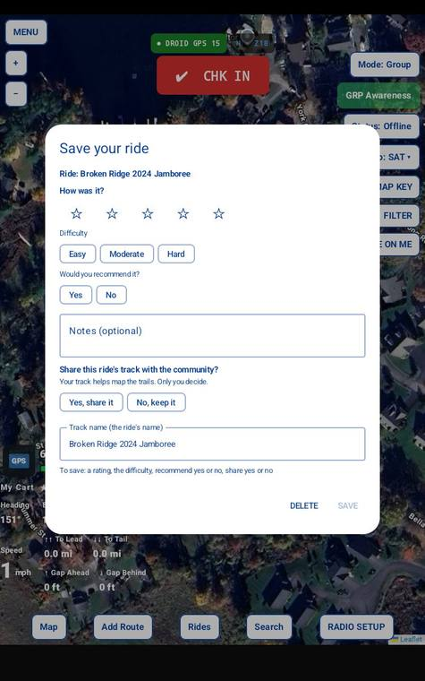

Save for scheduled ride

**Save your ride.** On a scheduled ride: rate it, choose the difficulty, say whether you recommend it, and whether to share the track with the community — then **SAVE** (the line above SAVE says what is still missing). With **No scheduled ride**, just name the track and SAVE.

What does it mean to me?

Your ride is filed under its name; your rating helps the next group decide, and only you decide whether your track is shared.

**More: What the end-of-ride form asks**

- **A ride:** the track is named after the ride — every rider's recording of it carries the same name.
- **A public ride:** rate it (1–5 stars), its difficulty, whether you would recommend it, notes if you like, and **Share this ride's track with the community?** — Yes or No, every time; there is no default. SAVE is available once they are done.
- **A private ride:** no survey and no sharing — your track stays on your tablet.
- **No scheduled ride:** you name the track; no survey, no sharing.

Your survey belongs to the ride — one per rider; saving again replaces it. The track is yours: only you decide whether it is shared. DELETE asks before throwing a recording away.

Carried from the 2.7b manual — check the wording.

**C · Mode — Android only or Group**

What is it?

Mode switches GroupTrack between its two ways of riding. **Android only**: you ride on your own with no radio, and the tablet's GPS places your cart. **Group**: you ride with others who carry mesh radios, and every cart in the group is on your map. Mode does not change carts or riders — it changes what GroupTrack does.

How do I use it?

1. Tap **Mode** on the right side. It switches to the other mode, and the button says which you are in.
2. **Android only**: the ride button is **REC**; GRP Awareness is grey. Maps, trails, routes, rides and search all work.
3. **Group**: the group buttons appear — **GRP Awareness**, **CHK IN**, **View: My Cart / Group** and **RADIO SETUP**.

Mode cannot be switched while you are recording: end the ride first. In Android only, the GPS lamp at the top (**DROID GPS n**) places your cart, so it should be green before you ride.

[figure not shown]

Android only: one rider, no radio — REC, GRP Awareness grey

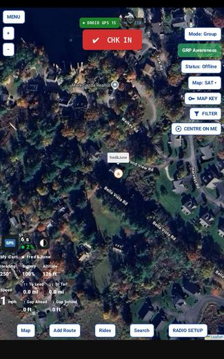

Group: riders with radios — CHK IN, GRP Awareness, View: My Cart / Group, RADIO SETUP

What does it mean to me?

The screen shows only what your kind of ride needs: nothing about radios when you ride alone, the whole group when you ride together.

**D · GRP Awareness — connect your radio**

What is it?

GRP Awareness is your link to your mesh radio. The button's colour tells you its state at a glance — **green**: your radio is connected and talking to GroupTrack; **red**: it is not — and a tap opens the panel where you connect, pair or forget a radio.

How do I use it?

Tap **GRP Awareness** on the right side (Group mode). The panel is shown below, with what to tap beside it. The lines under it lead on to each job in its own section: Bluetooth, FORGET, NODES, RADIO SETTINGS, and selecting a ride and applying its settings.

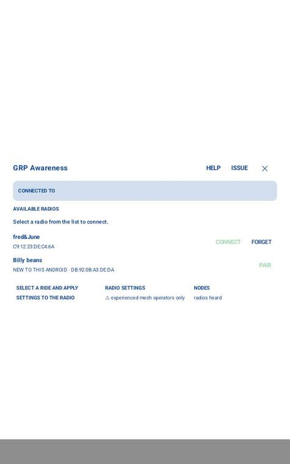

Radio settings connect, forget, pair. select a ride, radio settings nodes

**The panel.**

- **To connect your radio:** tap **CONNECT** beside it under AVAILABLE RADIOS. It moves to CONNECTED TO; the button turns green when it talks.
- **A radio new to this tablet** (marked NEW TO THIS ANDROID): tap **PAIR** and enter the radio's PIN when Android asks.
- **To change radios:** tap **DISCONNECT** beside the one connected — one radio at a time.
- **To remove a radio:** **FORGET** (its own section below).
- **No radios listed?** If Android has not let GroupTrack find nearby devices, the panel says so: tap **ALLOW**.

What does it mean to me?

You know before you roll out that your radio is talking — and so that the group can see you and you can see them.

**More: Radio range and group size**

**Range.** On a T1000-E, plan on about ¾ mile between riders in open country; terrain and trees shorten it, a clear line of sight lengthens it. Radios with a bigger antenna or more power reach further. (Estimates, being measured on real trails — Ride statistics shows yours.)

**Radios relay for each other.** A rider out of direct reach is still heard through the riders between you, so a strung-out group stays connected as long as no gap between riders is longer than a radio's reach.

**Strong radios make a backbone.** A radio with a good antenna — 1 watt, mounted high — reaches much further and hears weak radios better. Put strong radios at the lead, the tail and the middle of a long group. The leader's radio matters most: it carries the leader's track to everyone behind.

**Every radio on a ride must use the same setting.** GroupTrack sets it when the ride is applied; radios set differently cannot hear each other at all.

Carried from the 2.7b manual — check the wording.

**Bluetooth off**

What is it?

Your radio talks to the tablet over Bluetooth. GRP Awareness tells you when Bluetooth is off, and turns it on or off from the panel.

How do I use it?

- **To turn it on:** the panel says *Bluetooth is off*. Tap **BLUETOOTH**; Android asks *GroupTrack wants to turn on Bluetooth* — tap **Allow**. Your radios appear.
- **To turn it off** (no radio connected): under the radio list, tap **TURN BLUETOOTH OFF**. Android's Bluetooth page opens: use the switch at the top, then come back. A radio connected? DISCONNECT it first.

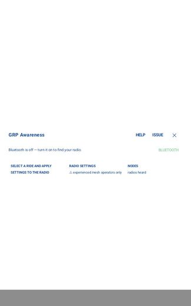

Bluetooth off: GRP Awareness says so — tap BLUETOOTH

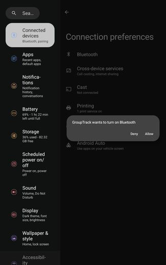

Android asks: GroupTrack wants to turn on Bluetooth — tap Allow

What does it mean to me?

Bluetooth on or off without leaving GroupTrack to hunt through Android's settings.

**FORGET**

What is it?

FORGET removes a radio from GroupTrack and from this tablet's Bluetooth pairings.

How do I use it?

1. In the GRP Awareness panel, tap **FORGET** beside the radio.
2. Confirm: **FORGET** (or CANCEL).
3. If Android needs you to do it, GroupTrack says so and opens Android's Bluetooth page: tap the radio, then **Forget**, and come back.

To use the radio again, **PAIR** it again.

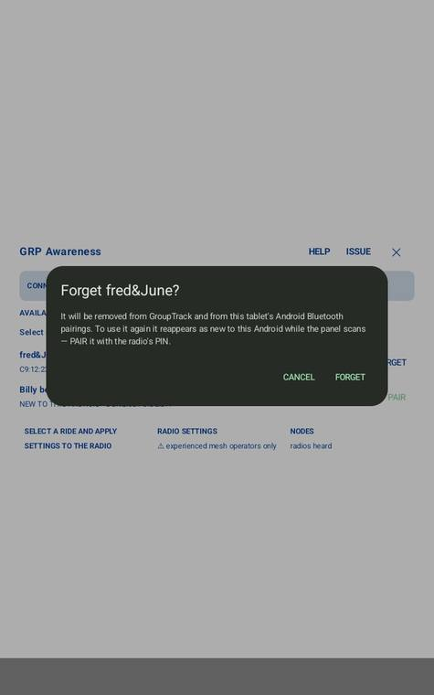

Forget

What does it mean to me?

A radio you sold, lent or replaced no longer shows up — and cannot connect by mistake.

**NODES**

What is it?

NODES lists every radio your radio has heard, with its details.

How do I use it?

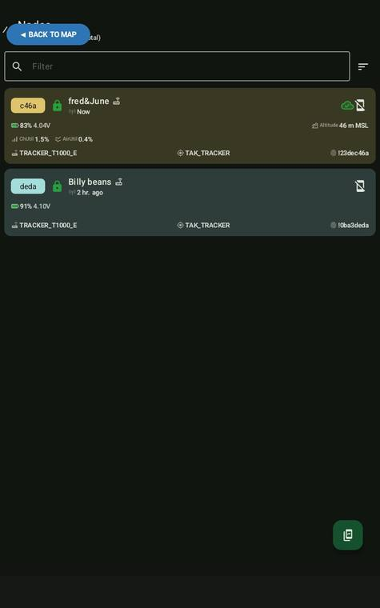

Node info

What does it mean to me?

You can check which riders' radios are on the air before you leave the trailhead.

**RADIO SETTINGS**

What is it?

The radio's own full settings, in the Meshtastic screens.

How do I use it?

In the GRP Awareness panel, tap **RADIO SETTINGS**. **For experienced mesh operators only:** GroupTrack sets everything a ride needs itself (N · RADIO SETUP), and a change made here can stop your radio from hearing the group.

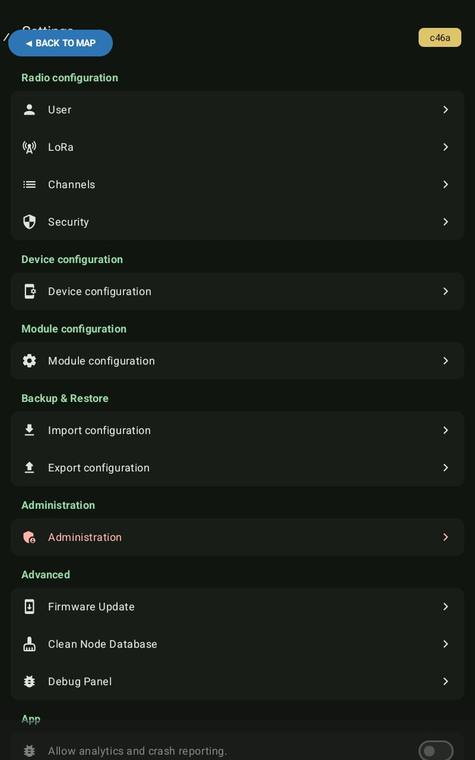

Mesh radio config

What does it mean to me?

Nothing to do here for an ordinary ride — it is there for those who know the radios.

**Select a ride and apply settings to the radio**

What is it?

Puts a ride's radio settings on your radio — the same job as RADIO SETUP › Configure radio (N).

How do I use it?

1. In the GRP Awareness panel, tap **SELECT A RIDE AND APPLY SETTINGS TO THE RADIO**.
2. Tap the ride (or the default settings), then apply. The radio is set up — about a minute, with its progress on screen.

Full steps: N · RADIO SETUP › Configure radio for rides.

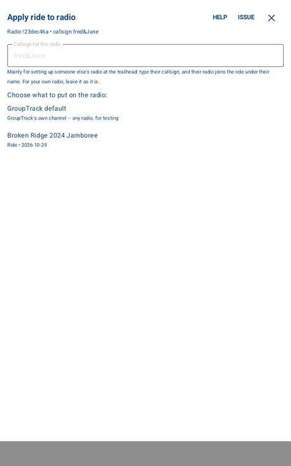

What does it mean to me?

Your radio is on the ride's network before you get to the trailhead.

**E · Status — Online or Offline**

What is it?

Status says whether GroupTrack is using the internet, and lets you switch it off on purpose. **Online**: maps and searches use the internet. **Offline**: GroupTrack uses only what is on the tablet — your downloaded maps and data.

How do I use it?

- **To try your offline maps before you leave:** tap **Status: Online**; it becomes **Status: Offline**. Look over the ride area: what you see is what you will have with no signal.
- **To go back online:** tap **Status: Offline**.

With no internet, GroupTrack is offline anyway and the button says so.

What does it mean to me?

No surprises when the signal goes: you have seen your maps work without it before you ride.

**F · Map type — SAT, TOPO, TOPO+**

What is it?

How do I use it?

1. Tap **Map: SAT ▾** (or TOPO, TOPO+).
2. Tap the type you want; the dot marks the one in use. The map switches and the list closes.

Which source each type uses is set in Map › Map source (J). Panels change colour with the map type so they stay readable.

[figure not shown]

Map type to be displayed selector

What does it mean to me?

Satellite to see the ground, topo to see the shape of it — one tap to switch.

**G · MAP KEY — what the lines and symbols mean**

What is it?

MAP KEY explains everything drawn on the map — the trails by category, your tracks and routes, the lines drawn while you ride, and the group's carts — and lets you change how each one looks.

How do I use it?

Tap **MAP KEY** on the right side. It stays open beside the map and scrolls; each part is shown below with what to do beside it.

[figure not shown]

Maps key decode artifacts

**Reading the map:** find the line's colour and pattern here to know what it is — the trails, motorized first.

- **To change how a kind of line looks:** tap **STYLE ›** on its row. Style a row opens (below): choose the colour, pattern and thickness; the map redraws as you choose.
- **To keep the key in view while you look:** drag it by **☰ MOVE**; tap **HIDE** to fold it to its title and again to open it.
- **To close it:** ✕.

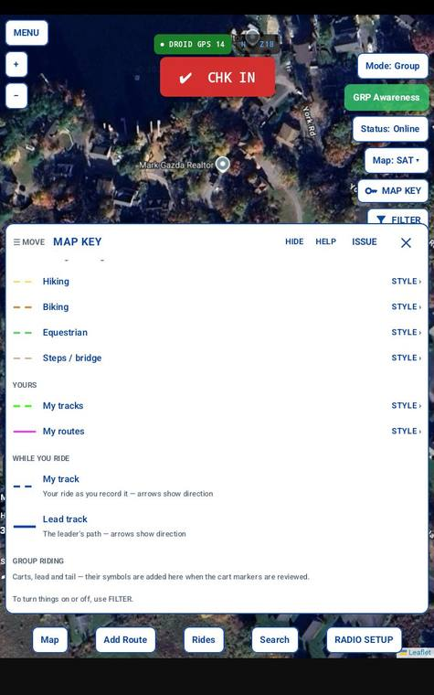

Decoder screen 2

**Scroll down for your own lines and the group.**

- **YOURS** — your tracks and routes. Tap **STYLE ›** to make them stand out from the trails.
- **WHILE YOU RIDE** — **My track** (your ride as you record it) and the **Lead track** (the leader's path). The arrows on them show the direction travelled.
- **GROUP RIDING** — the carts, lead and tail.

**To turn any of these on or off,** use FILTER (H) — the key only explains and styles them.

What does it mean to me?

Every line and symbol on your map is explained, and you can make the ones that matter to you stand out.

**Style a row**

What is it?

Changes how one kind of line or symbol is drawn — its colour, pattern and thickness.

How do I use it?

1. In MAP KEY, tap **STYLE ›** on the row.
2. Tap a colour, a pattern and a thickness. The map redraws as you choose.
3. Close with ✕; your choice stays.

[figure not shown]

Setting display value for screen content

What does it mean to me?

The trails you ride, or your own tracks, stand out the way you like them.

**H · FILTER — what shows on the map**

What is it?

FILTER chooses what is drawn on the map: each type of thing (trails, tracks, routes, waypoints), each kind of trail, public and private land, and where your offline maps reach. It stays open beside the map while you change it, so you see the result as you tick.

How do I use it?

Open **FILTER** on the right side. The panel scrolls; each part is shown below with how to use it.

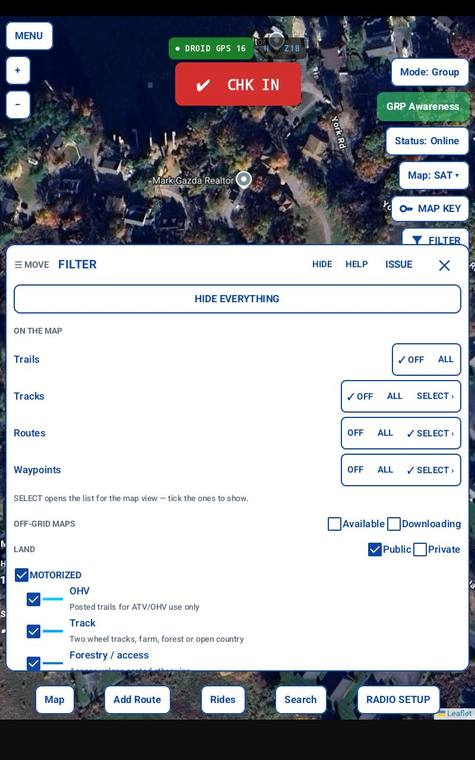

Map filter screen 1 scrolls

**The top of FILTER.**

- **To clear the map:** tap **HIDE EVERYTHING**. The button becomes **SHOW AGAIN — restore what was on**: tap it to bring back exactly what was showing.
- **To show or hide a whole type:** on its line under ON THE MAP, tap **ALL** to show every one or **OFF** to hide them. The tick shows the current setting.
- **To show only some tracks, routes or waypoints:** tap **SELECT ›** on that line. The list of that type in the map view opens: tick the ones you want (SELECT ALL and DESELECT ALL tick or clear the lot; FIT fits the map to the ticked ones), then tap **✕** — the ticks are applied. Which trails show is chosen in the list further down, not with SELECT.
- **To see where your offline maps reach:** tick **Available** (areas downloaded) and / or **Downloading** (areas still coming). Untick to remove the outlines.
- **To see only trails on private land:** untick **Public**. **Only public trails:** untick **Private**. One of the two always stays ticked.

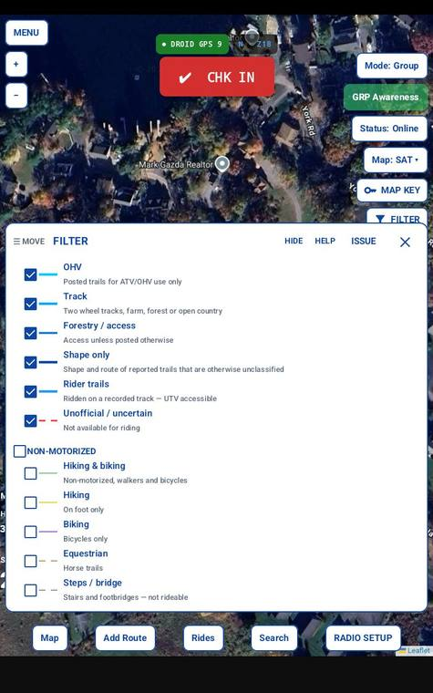

Filter screen 2

**Scroll down for the trail categories.**

- **To hide one kind of trail** (for example Unofficial / uncertain): untick it. Tick it again to show it.
- **To show or hide a whole group:** tap its heading — **MOTORIZED** or **NON-MOTORIZED**. If every kind in the group is on, the tap turns them all off; otherwise it turns them all on.
- **To check what a category means:** read the line under its name — for example Rider trails are ridden on a recorded track and UTV accessible; Steps / bridge are not rideable.

The map changes as you tick. The colours of each kind are changed in MAP KEY (G).

What does it mean to me?

A map that shows only what matters for the ride in front of you. You can check which trails cross private land before you go, hide what you cannot ride, and see where your offline maps run out before you lose signal.

**I · CENTRE ON ME**

What is it?

The button says what the map is doing. **CENTRE ON ME**: the map is not following you. **FOLLOWING ME**: it keeps your cart in the middle (readout on MY CART). **FOLLOWING GROUP**: it keeps the whole group in view (readout on GROUP).

How do I use it?

- **To bring your cart back to the middle:** tap **CENTRE ON ME**. The map follows you.
- **To look around:** move the map with your finger — following stops.

Following starts by itself when you start recording; while recording it starts again 15 seconds after your last touch.

What does it mean to me?

On the trail you always start on yourself: look around, and the map comes back to you.

**J · Map — downloads, imports and map recovery**

What is it?

**Map**, first on the bottom bar, holds every map job: what is downloading, the map source, downloading and removing maps, map recovery, and every import.

How do I use it?

Tap **Map**, then the line for the job; the menu closes and the job opens. The menu scrolls — the two screens below show where each job is.

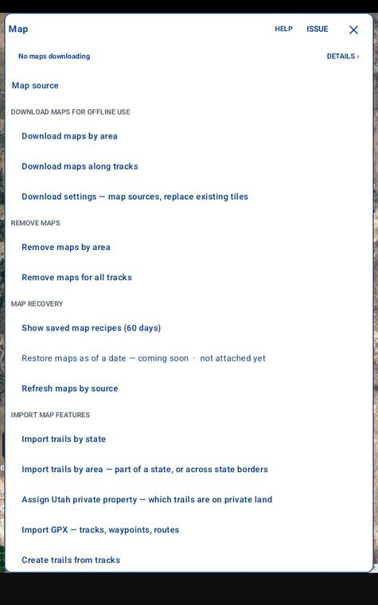

Screen 1 maps menu

**Tap a line to start that job** — the menu closes and the job opens; each job is explained in its own section below.

- **To see what is downloading:** the first line says it (No maps downloading, or the progress); tap **DETAILS ›** for the queue.
- **To change which maps you see:** Map source.
- **To get maps before you lose signal:** Download maps by area (draw a box) or Download maps along tracks (pick your tracks); Download settings chooses the sources.
- **To free space:** Remove maps by area, or Remove maps for all tracks.
- **To repair or recover maps:** Show saved map recipes; Refresh maps by source. (Restore maps as of a date is coming soon and cannot be tapped yet.)

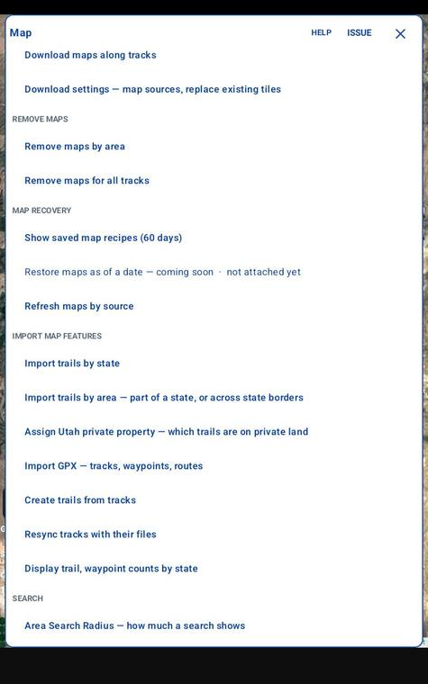

Screen 2 maps functions

**Scroll down for the imports.**

- **To load trails:** Import trails by state (a whole state), or Import trails by area (part of a state, or across state borders).
- **To mark private land in Utah:** Assign Utah private property.
- **To bring in a GPX file** (from Gaia, onX or a friend): Import GPX.
- **To turn ridden ground into trails:** Create trails from tracks. **If a track is missing from the map:** Resync tracks with their files.
- **To see what you have:** Display trail, waypoint counts by state.
- **To set how much map a place search shows:** Area Search Radius.

What does it mean to me?

Get the maps and trails you need before you lose signal, all from the map you ride with.

**Create trails from tracks**

What is it?

Adds rider trails from your recorded tracks — the ground you rode where no trail is published. GroupTrack now does this automatically whenever a track is recorded or imported.

How do I use it?

**If you imported tracks before 5 October 2026, run this task once:** Map › **Create trails from tracks** › **START**. Running it again does no harm.

[figure not shown]

Add trails if no trails exist in recorded area

What does it mean to me?

Every place you have ridden shows as a trail, including your oldest tracks.

**Download maps along tracks**

What is it?

Downloads the maps along your routes and tracks — a corridor just wide enough for the ride, not the whole area round it.

How do I use it?

1. Map › **Download maps along tracks**.
2. Tick the tracks (**ALL** for every one; **Search tracks by name** to find one).
3. Check the sources (CHANGE alters them for this download only). The line above shows how many jobs it makes.
4. **CONTINUE** — the corridors go into the download queue.

[figure not shown]

Corridor download from routes and tracks select one or all and required maps for that route or track are placed in download queue

What does it mean to me?

The maps for a ride download in a fraction of the time and space of a whole area.

**Download maps by area**

What is it?

Downloads the maps for an area you draw, so they work with no signal.

How do I use it?

1. Map › **Download maps by area**.
2. Draw a rectangle on the map with your finger round the area (**CLEAR** to draw again).
3. The summary shows how many tiles per source and the sources it will use (from Download settings). **CHANGE** alters them for this download only; **Show details** lists the zoom levels.
4. **PROCEED** — the maps go into the download queue.

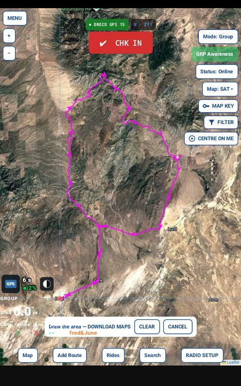

Download maps by area. draw boundary of area to be downloaded

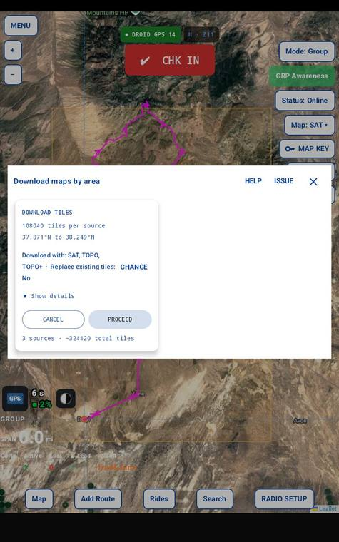

Draw area rectangle with your finger. this screen appears select proceed and maps are placed in download queu

What does it mean to me?

The whole area is on your tablet before you leave signal behind.

**Download settings**

What is it?

The defaults every download starts from: which map sources (SAT, TOPO, TOPO+) it downloads, and whether it replaces tiles you already have.

How do I use it?

Map › **Download settings**: tick the sources, then **SAVE**.

**Replace existing tiles — leave it off.** Off, a download of an area or a corridor skips the tiles you already have, which makes it much faster. Tick it only when you want to change the imagery on purpose. Each download shows these settings, and its CHANGE alters that download only.

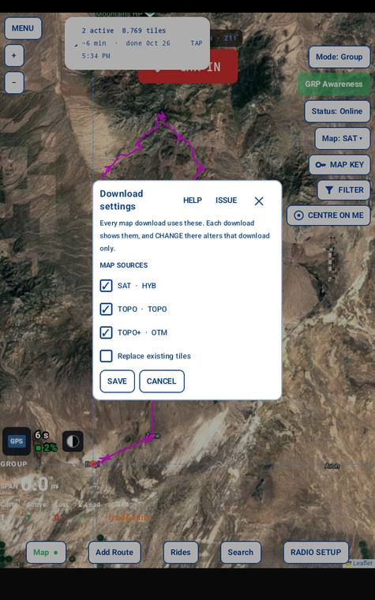

Default setting for what maps are processed for off line access

What does it mean to me?

Set it once; downloads go quickly and never spend time on maps you already have.

**Downloads — the queue**

What is it?

The download queue: what is downloading, how many tiles, how fast, and when it will be done.

How do I use it?

The first line of the Map menu shows it (No maps downloading, or the progress); a small box on the map shows it too. Tap **DETAILS ›** (or the box) for the queue:

- The top line: jobs active, tiles to go, the time left and when it will be done.
- **ALL / AREA / CORR / RFSH / DEL** show one kind of job (area downloads, corridors along tracks, refreshes, removals).
- **HOLD** pauses the queue (RELEASE starts it again); **X** on a job cancels it; **CANCEL ALL** cancels everything waiting; **CLEAR ALL** clears the completed list.

[figure not shown]

Queued downloads being processed

**The queue.** Top line: jobs active, tiles to go, the time left and when it will be done. ALL / AREA / CORR / RFSH / DEL show one kind of job. HOLD pauses; X cancels a job; CANCEL ALL cancels everything waiting; COMPLETED (folded) lists finished jobs; CLEAR ALL clears it.

What does it mean to me?

You always know when your maps will be ready — and downloads carry on while you use the map.

**Import GPX — tracks, waypoints, routes**

What is it?

Brings in a GPX file — tracks, waypoints and routes from Gaia, onX or a friend.

How do I use it?

**Easiest:** tap the GPX attachment in your email and choose **Open with GroupTrack**. Or:

1. Map › **Import GPX**. A notice explains the Android file picker (how to come back: the back arrow, or a swipe in from the right edge). **CONTINUE**.
2. Choose the file(s) in Downloads.
3. Back in GroupTrack, each file is listed: tick **IMPORT**, and **MAPS** to download the maps along it. **Import Selected**.
4. If MAPS was ticked, confirm the map download (sources; CHANGE for this download only) and **PROCEED**.
5. **Import Complete** shows what was new, a duplicate, skipped or failed. **DELETE FILES & CLOSE** or **KEEP FILES & CLOSE**.

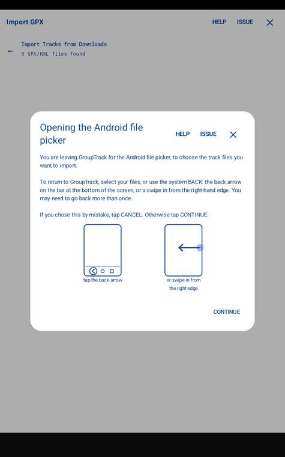

Import gpx files

**Before the picker,** GroupTrack tells you that you are leaving it for Android's file picker, and how to come back: the back arrow on the bar at the bottom of the screen, or a swipe in from the right edge. Tap **CONTINUE**.

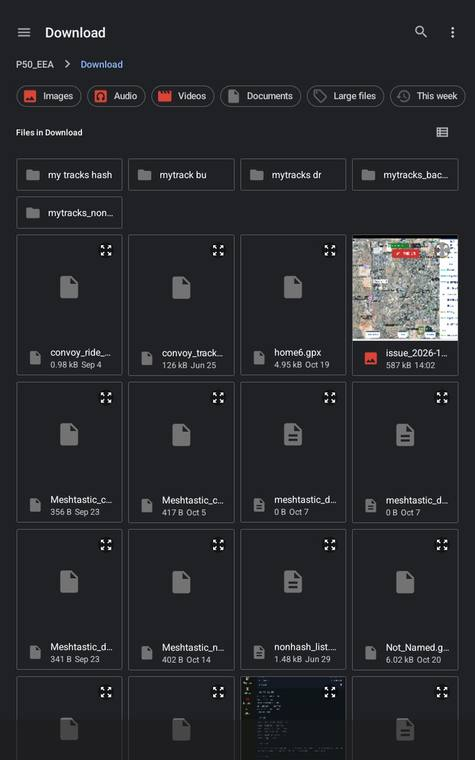

Android file picker in downloads to select file being processed

**Finding your GPX file in a busy Downloads folder.** The picker shows every file, so narrow it:

- **Search by name:** tap 🔍 at the top right and type **gpx**. Only files with that in their name are left. Tap the one you want.
- **Just downloaded it?** Tap **This week** in the row of buttons under the folder name: only files from the last seven days are left.
- **Names cut short?** Tap the list button at the right of **Files in Download**: one file per line, with its full name, size and date.
- **Not in Downloads?** Tap ☰ at the top left and choose where it is — for example Google Drive.
- **Changed your mind?** The back arrow, or a swipe in from the right edge, takes you back to GroupTrack without a file.

To bring in several files at once, touch and hold the first, then tap the others, then **Select**.

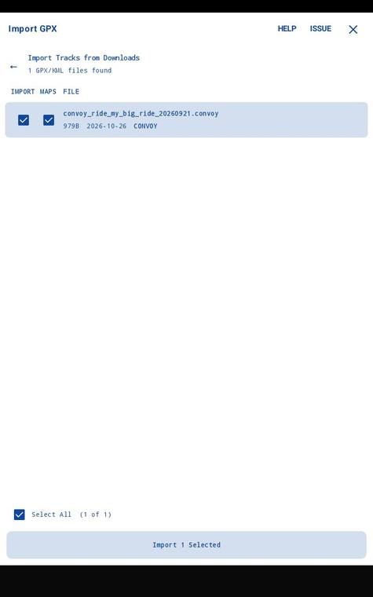

Selected file processing download gpx, include maps

**Back in GroupTrack,** each file you picked is listed.

- **IMPORT** ticked: the file is brought in. Untick a file to leave it out.
- **MAPS** ticked: the maps along it are downloaded too.
- Tap **Import Selected**.

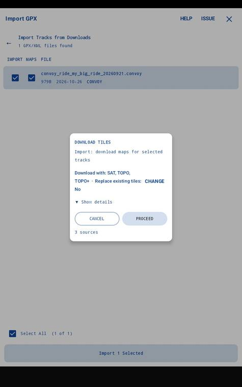

Confirmation of corridor maps

**If MAPS was ticked,** confirm the download: the map sources it will use (CHANGE them for this download only), then **PROCEED**. The maps join the download queue.

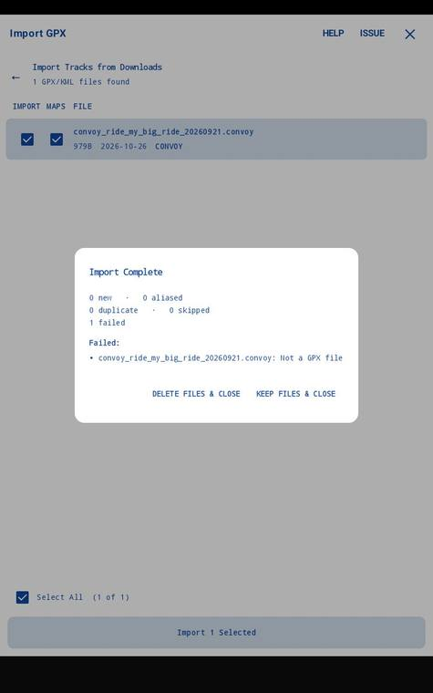

Import completed save gpx file source in downloads

**Import Complete** counts what happened to each file:

- **new** — added to My tracks.
- **aliased** — already in My tracks under another name; linked to it.
- **duplicate** — already there; nothing changes.
- **skipped** — not ticked.
- **failed** — not imported, with the reason. Here a ride file was picked: *Not a GPX file*. Import it with Rides › Import a ride.

**DELETE FILES & CLOSE** removes the picked files from Downloads; **KEEP FILES & CLOSE** leaves them there.

What does it mean to me?

What you planned in another app rides with you in GroupTrack, with its maps.

**Import trails by area**

What is it?

Loads the trails for part of a state, or an area across state borders, from every source that covers it.

How do I use it?

1. Map › **Import trails by area**. Draw a rectangle round the area (**CLEAR** to draw again).
2. The list shows every state and source your box touches. A state you already imported whole starts unticked. **Untick anything you do not want** — for example a state the box only clips.
3. **START**. Each source is processed in turn; when it finishes it shows what each added.

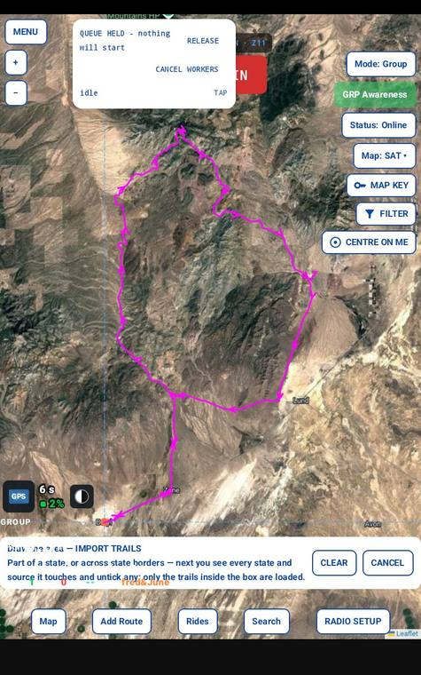

Import trails by area

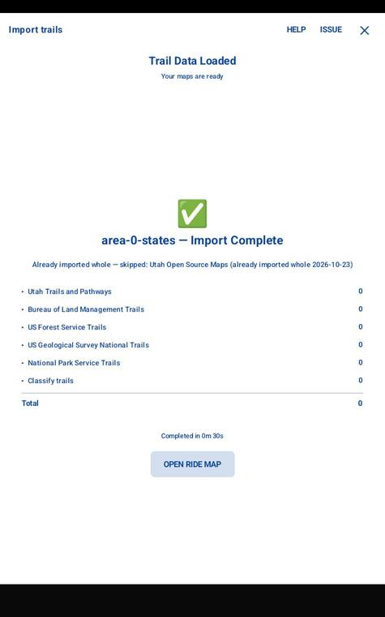

Import trails by area completed

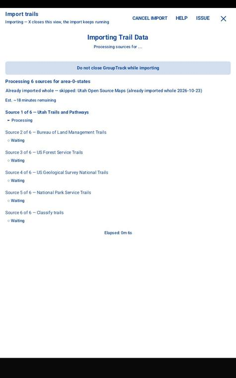

Import trails by area processing

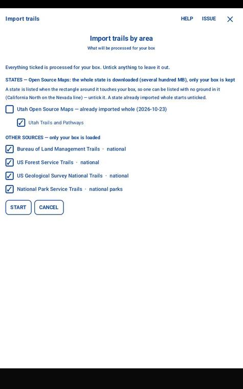

Summary of data to be processed

What does it mean to me?

Trails for the area you ride, without downloading whole states you do not need.

**Import trails by state**

What is it?

Loads every trail source for a state onto your tablet — the trails the maps do not show.

How do I use it?

1. Map › **Import trails by state**. GroupTrack offers your home state from your location; **Select a different Home state** to choose another.
2. Tap **LOAD … TRAIL DATA**. Internet is needed; it takes several minutes per source.
3. Each source is processed in turn. **Keep GroupTrack open while importing**; ✕ closes the view and the import keeps running.
4. When it finishes, each source shows how many trails it added (and how many you already had). **OPEN RIDE MAP**.

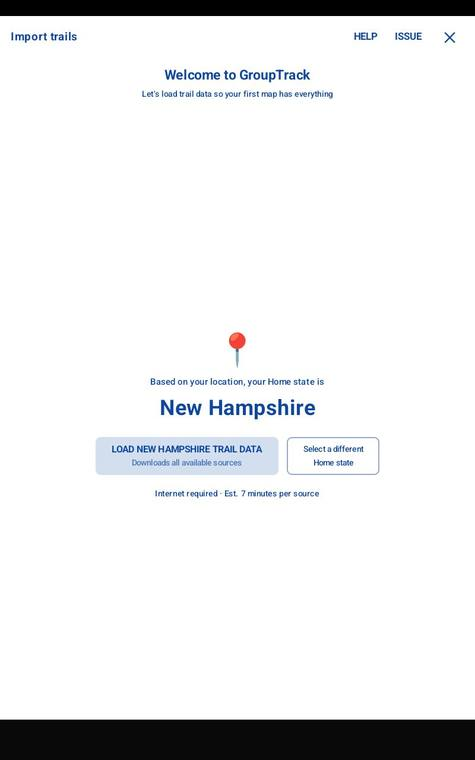

Import trails by state

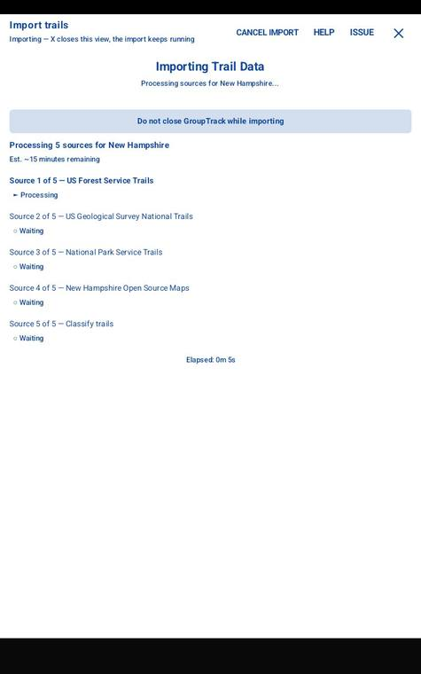

Importing state trails processing

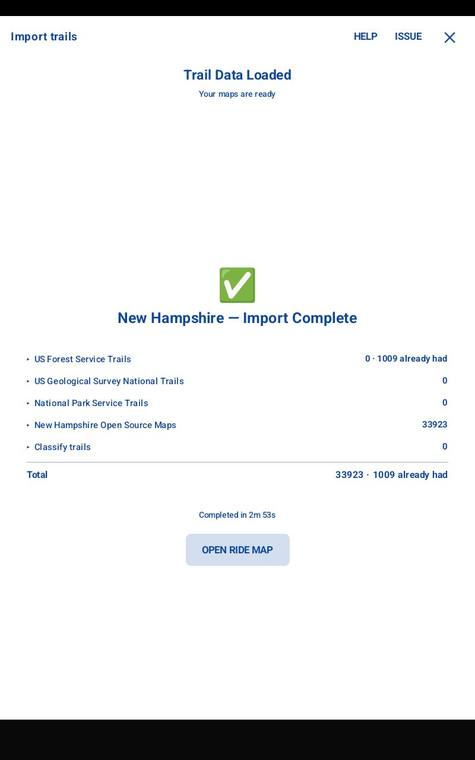

State import trails summary

What does it mean to me?

Every published trail in your state is on your map, with no signal needed.

**Map source**

What is it?

Which map source each map type uses — the satellite images for SAT, and the topo maps for TOPO and TOPO+.

How do I use it?

Map › **Map source** (or Settings › Change Map Sources). Pick the map type, choose its source and confirm. If you already have maps from the old source, GroupTrack offers to bring them up to date from the new one (see Refresh maps by source).

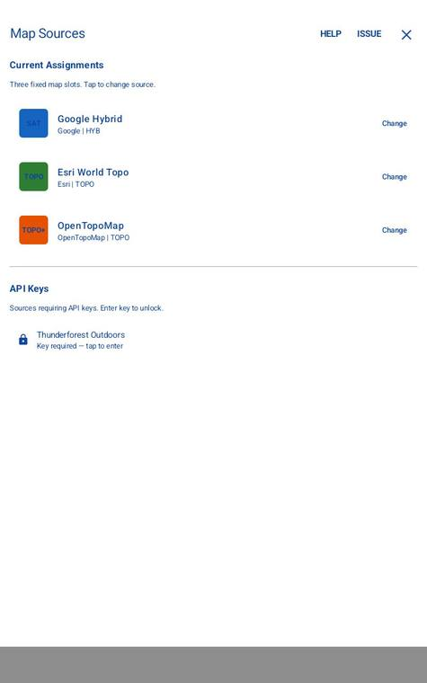

Change map source screen 1

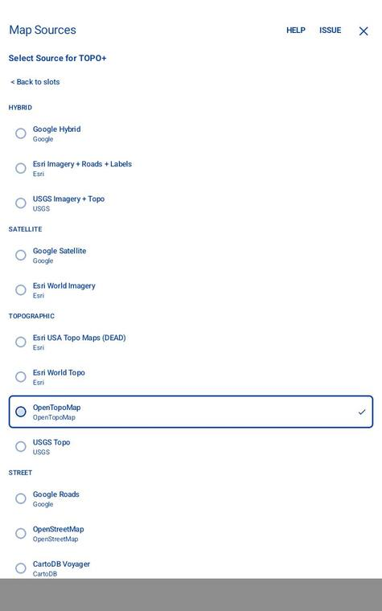

Change map source screen 2

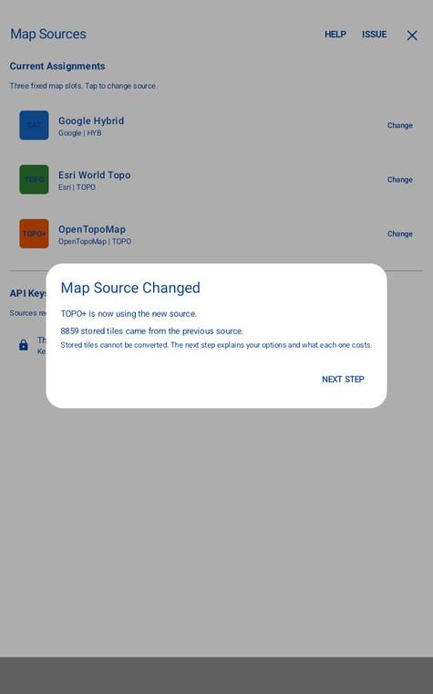

Change map source screen 3

[figure not shown]

Change map source screen 4

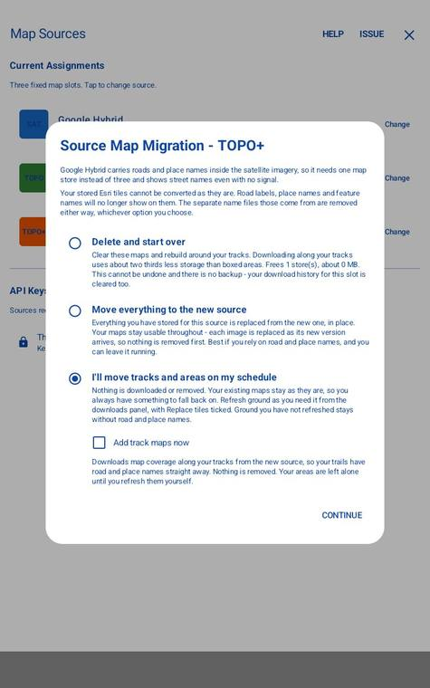

Change map source screen 5

[figure not shown]

Map source change final screen

What does it mean to me?

You choose the imagery you ride with, and your downloaded areas follow the choice.

**Refresh maps by source**

What is it?

Downloads again every tile of one map source that you already have, and replaces them with fresh ones. It works on the areas you already have — you draw nothing.

How do I use it?

1. Map › **Refresh maps by source**, and choose the map type (SAT, TOPO, TOPO+).
2. GroupTrack adds up the tiles that source actually holds, zoom level by zoom level, and how many jobs it makes. Only those are downloaded again — ground with no tiles is never requested.
3. **PROCEED TO COPY**. The job runs in the download queue, which keeps its time estimate up to date.

Your maps keep working while it runs: each tile is replaced in place, so nothing is removed first.

[figure not shown]

Refresh maps by source

What does it mean to me?

When a source has newer imagery, your maps look wrong, or you switch a map type to a new source, all your areas are brought up to date at once.

**Remove maps by area**

What is it?

Removes the downloaded maps inside an area you draw, to free space.

How do I use it?

Map › **Remove maps by area**. Draw a rectangle round the area (**CLEAR** to draw again), confirm, and the maps inside it are removed.

[figure not shown]

Draw a box to remove maps by area

What does it mean to me?

You free space on your tablet without touching the maps you still need.

**Remove maps for all tracks**

What is it?

Removes the maps downloaded along your tracks and downloads them again — used when a map source changes.

How do I use it?

Map › **Remove maps for all tracks**. GroupTrack holds the queue, scans your tracks and shows how many tiles are on the tablet. **PROCEED**: the track coverage is removed and downloaded again; tracks reappear one at a time as each finishes, and your area maps stay visible the whole time. Downloads continue in the background, and resume if the app or tablet restarts.

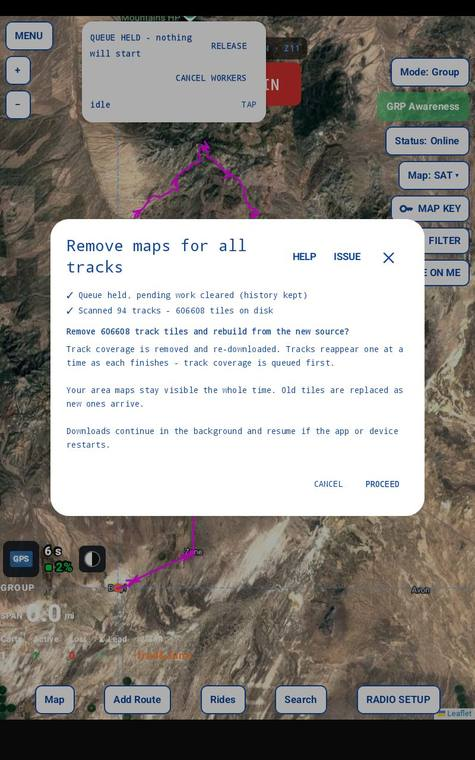

Confirmation of track tiles removal

What does it mean to me?

Your track maps come back from the new source without you redrawing anything.

**Resync tracks**

What is it?

An older check that every track you recorded is in My tracks and in GroupTrack's database and folder.

How do I use it?

**Only when GroupTrack support asks you to:** Map › **Resync tracks with their files** › **START**.

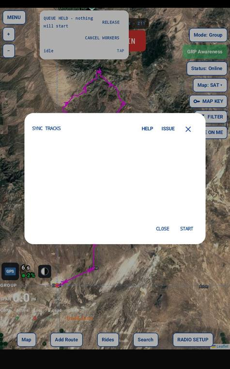

Resync tracks to all tracks in my tracks exist in db

What does it mean to me?

A repair tool support can use if a track goes missing.

**Area Search Radius**

What is it?

How much map a search shows around the place it finds.

How do I use it?

Map › **Area Search Radius**. Drag the slider: towards **Z12** shows a wider area, towards **Z18** closer (Z13 is standard). **SAVE**.

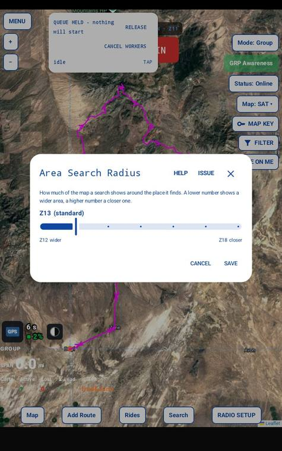

Area search radius

What does it mean to me?

A place search lands at the zoom you want — wide to see an area, close to see a trailhead.

**Saved map recipes**

What is it?

A daily record of what your maps cover, kept for 60 days: for each day, the map types and the number of tiles. It is a few kilobytes, not the maps themselves.

How do I use it?

Map › **Show saved map recipes (60 days)**. Read the list; CLOSE. Restoring your maps as they were on a date is coming soon.

[figure not shown]

60 days of map recovery positions

What does it mean to me?

If your tablet ever loses its maps, they can be downloaded again from the record instead of rebuilt by hand.

**Trail and waypoint counts by state**

What is it?

What is on your tablet: trails (and how many are on private land), waypoints and map points — and, state by state, what each import added.

How do I use it?

Map › **Display trail, waypoint counts by state**. Scroll to read it; ✕ closes.

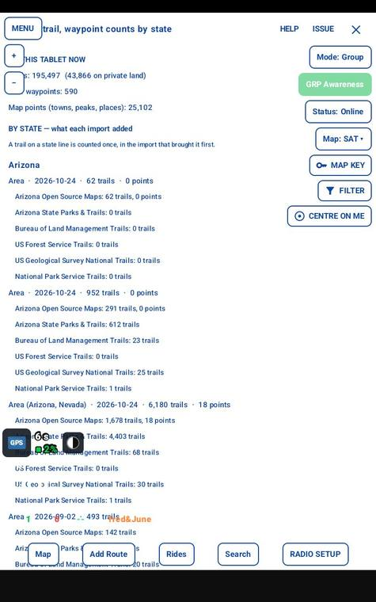

Display trail counts by state

What does it mean to me?

You can see what you have, and where it came from.

**Assign Utah private property**

What is it?

Marks which Utah trails are on private land, from Utah's land ownership data. Town street grids on private land become residential roads, and every trail also gets its type and use. Nothing is deleted.

How do I use it?

Map › **Assign Utah private property**. The panel says how old the land ownership data on your tablet is; tick **Download the latest land ownership data first** to update it. **ASSIGN**. It takes about 10 minutes for the whole state.

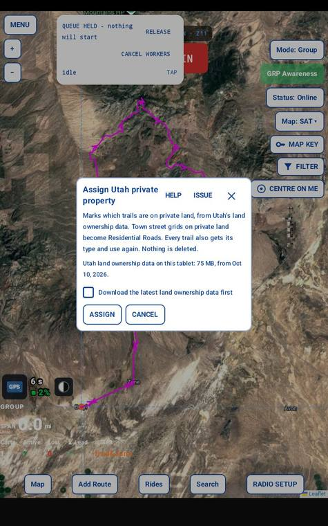

Processing utah private property

What does it mean to me?

FILTER can show you exactly which trails cross private land before you ride.

**K · Add Route — making a route**

What is it?

Add Route makes a route — the line a ride follows. Let GroupTrack design it for you, or draw it yourself.

How do I use it?

Tap **Add Route**, second on the bottom bar, then:

- **AI route design** — GroupTrack designs up to 6 routes and you keep the ones you like.
- **Build it myself** — tap points on the map; the route follows the trails between them.
- **Clear leftover routes** — removes unfinished routes and AI routes you did not keep.

Once you check in, this button becomes **View: My Cart / Group**.

[figure not shown]

Build route menu

Tap the way you want to make the route.

What does it mean to me?

A route for any ride in minutes, and a route left unfinished is waiting for you next time — a crash never costs you the points you dropped.

**AI route design**

What is it?

GroupTrack designs routes from what you ask for: where, how long, what you want to see, and where to finish. It suggests up to 6 and you keep the ones you like.

How do I use it?

Add Route › **AI route design**, then follow the screens below — what to do on each is beside it.

[figure not shown]

Ai route planner intro, you can turn off when you are comfortable with the function

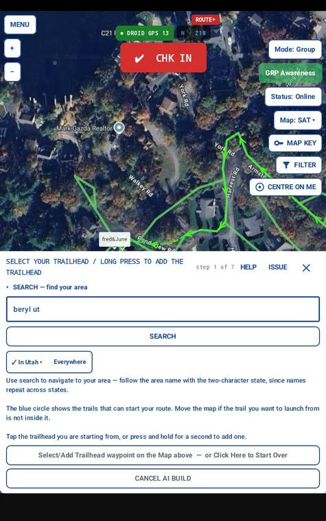

Search to position to the area you wish to ride

**Search** for the area you want to ride; the map moves there.

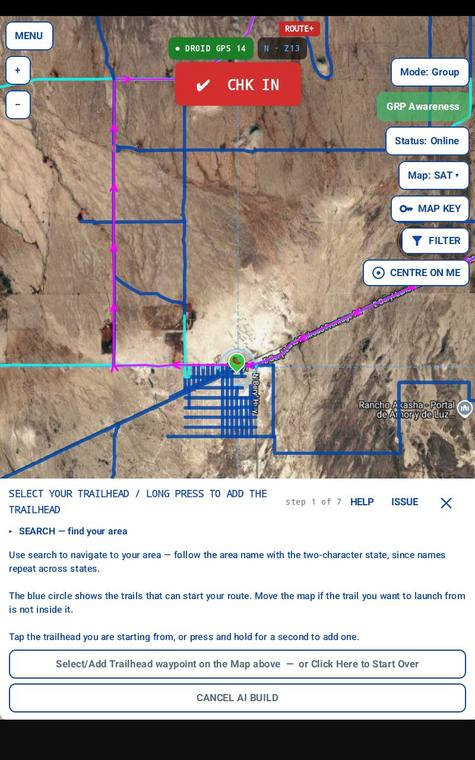

Select an existing trailhead or create a trailhead within ½ mile of trail

Tap an existing **trailhead**, or make one — there must be a trail within ½ mile (2,640 ft).

[figure not shown]

Define the desired length of your ride

Set **how long** a ride you want.

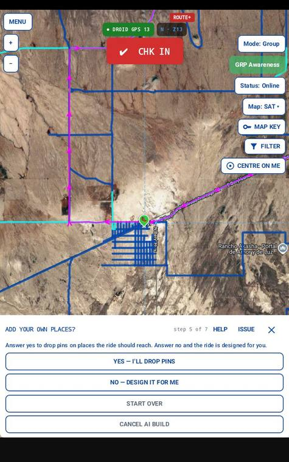

Next you can optionally drop up to 5 pins in areas you want to see

Optional: tap the map to drop up to **5 pins** where you want to go.

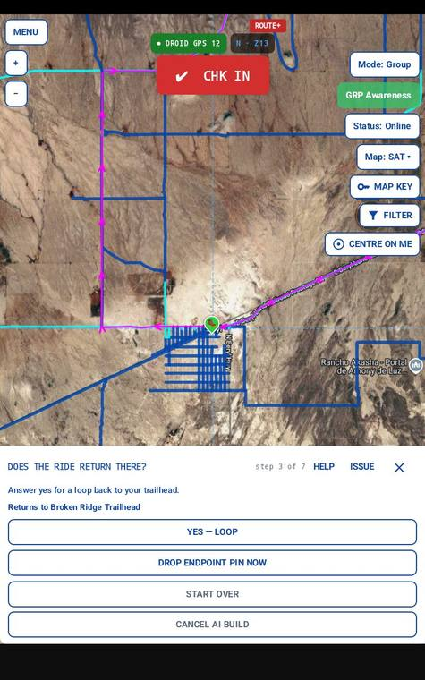

Next are you riding to return to this trailhead or else drop a pin where you would like to end this ride

**Finish** back at the trailhead, or drop a pin where you want to end.

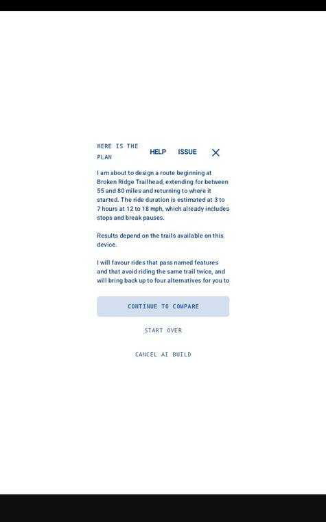

I selected design route for me. this screens summarizes what will be created

[figure not shown]

Summary of our route

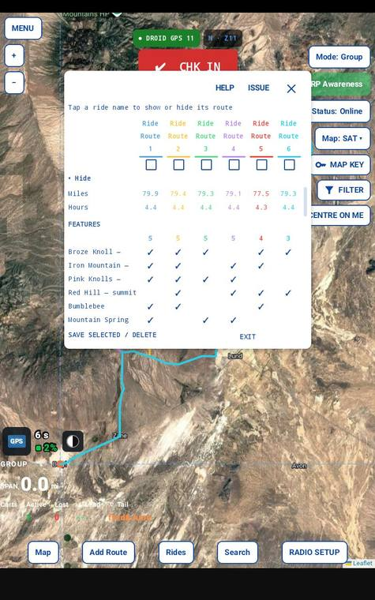

Up to 6 routes will be suggested and displayed in the compare function

Up to **6 routes** come back in the compare panel.

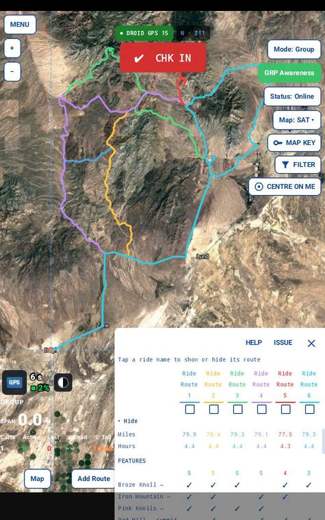

You can drag the compare panel around the screen so you can see trails click on the route name and trails will toggle on and off the map

**Drag** the panel to see the map; tap a route's name to show or hide it.

[figure not shown]

Features covered by each route are identified in the grid for your evaluation

The **features** each route passes, side by side.

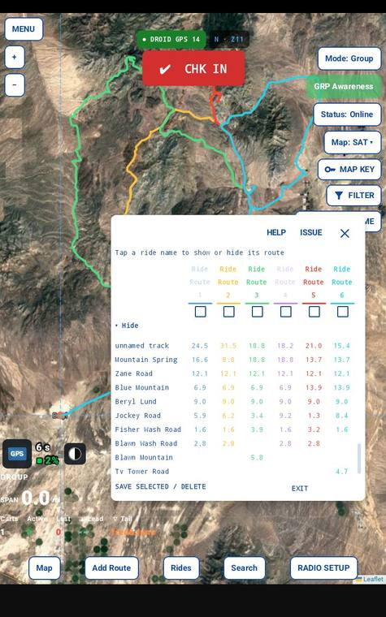

Mileage ride on each trail is also compared

The **miles** on each trail, side by side.

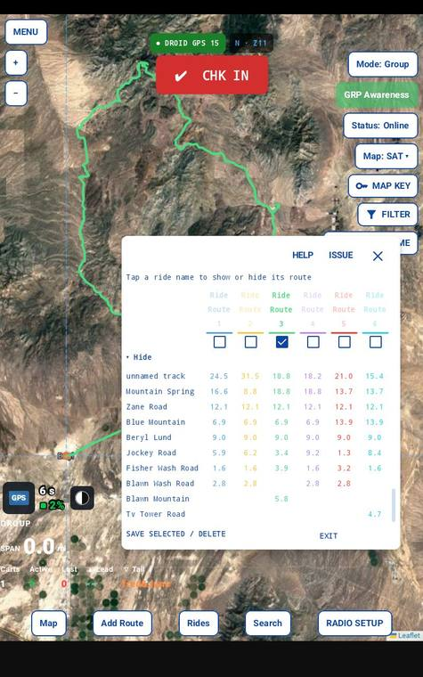

Once you have decided which route to ride you simply check the box to save that route

**Tick** the routes you want to keep.

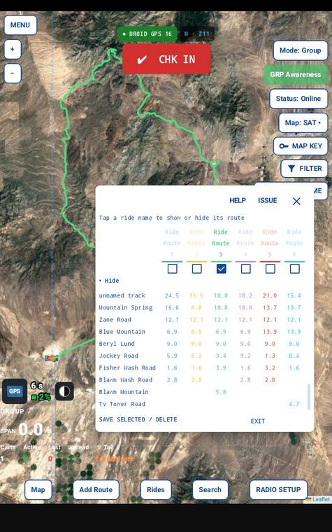

Once you have selected routes to be saved they will be saved as 1,2,3 appended after your area name. those not saved are deleted

Kept routes are saved as your area name 1, 2, 3…; the others are deleted.

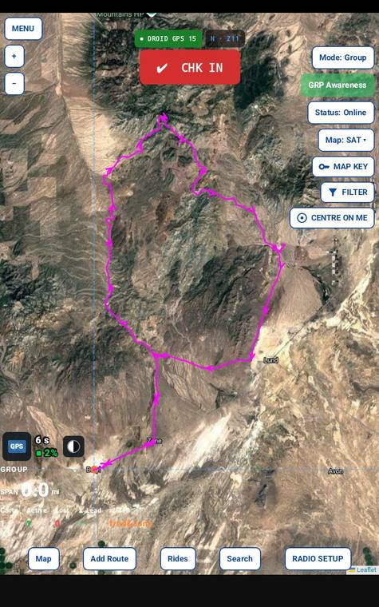

Here is my newly created route. if you click on route you will see details

Your new route on the map — tap it for its details.

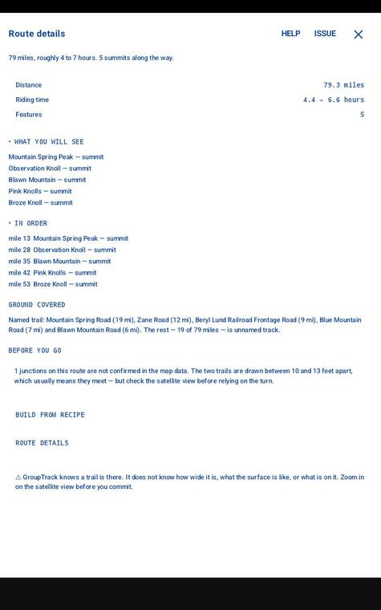

Build from recipe will rerun the parameters of your ride request and create new rides again in this area

**Build from recipe** runs the same request again here for new routes.

What does it mean to me?

A ride designed around the trails, the length and the sights you want, compared side by side before you choose. The request is kept as a **recipe**: **Build from recipe** runs it again in the same area — the same route, and up to 5 others.

**More: The trailhead in AI route design — ½ mile**

The trailhead you choose needs a trail on the map within its **half-mile circle**; if none is shown, GroupTrack says so — turn the trail types on in FILTER, or choose another spot.

Carried from the 2.7b manual — check the wording.

**Build it myself**

What is it?

You draw the route: tap points on the map, and GroupTrack joins them along the trails, tracks or routes between them.

How do I use it?

Add Route › **Build it myself**, then follow the screens below. A route is saved with its trailhead — its first point: a trailhead already within 0.1 mile (528 ft) is reused; otherwise GroupTrack makes one and asks only for its name.

[figure not shown]

Follow route, track or trail to build a route. tap to drop new points. will snap to existing trail or track, straight lines if no trails exist or your path cannot be twermined

**Tap** to drop each point. The route follows the trail or track; where there is none it draws a straight line.

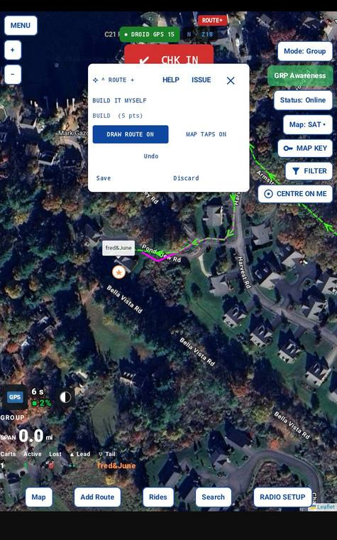

Drop pins to create a route following trail or track. save or discard at the end of your session

Keep tapping to the end. ❓ to confirm: how to take a point back

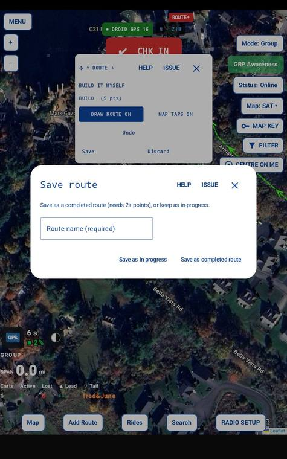

Saves as work in progress if you have not finished your route, or as a completed route when you are done

**Save** as a finished route, or as work in progress to finish later — or **discard** it.

What does it mean to me?

Exactly the route you want, along real trails — and never two trailheads a few yards apart.

**More: Every route has a trailhead — the 0.1 mile rule**

A route is saved with its trailhead: its first point. If a Trailhead waypoint is already within **0.1 mile** of it, that one is used; otherwise GroupTrack creates one there and asks only for its name — so you never get two trailheads a few yards apart. Every ride built on the route uses that trailhead (see Create a ride — the ½ mile rule).

Carried from the 2.7b manual — check the wording.

**Clear leftover routes**

What is it?

Removes routes left in progress and AI routes you did not keep.

How do I use it?

Add Route › **Clear leftover routes**. GroupTrack asks first. ❓ to confirm: does it list what it will remove?

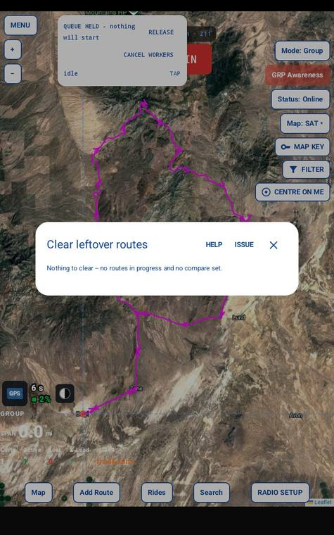

Clear leftover routes

What does it mean to me?

Your route list holds only the routes you meant to keep.

**L · Rides**

What is it?

A ride is everything a group needs to ride together, in one package: the route, the trailhead, the date and time, the maps and the radio setup. Rides is where you make, send, receive and look after them.

How do I use it?

Tap **Rides**, third on the bottom bar: **Create a ride**, **My rides**, **Import a ride**, and **Email last ride statistics to GroupTrack**. Once you are checked in, **View checked-in carts / change roles** is added at the top.

[figure not shown]

Rides before check-in. no view registered rider function

Before check-in: tap the job you want.

[figure not shown]

Rides after check-in view registered riders

Checked in: **View checked-in carts / change roles** is at the top.

[figure not shown]

Emailing ride statistics to grouptrack

**Email last ride statistics to GroupTrack**: your email app opens with the map, the ride statistics, the lead track and your last track. Nothing is sent until you tap Send.

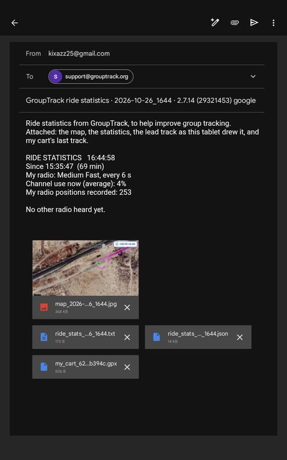

Ride statistics email

The email, ready to send. Please send it after a ride — it is how we improve group tracking.

What does it mean to me?

The organizer sends a ride once; each rider opens it with one tap — and after the ride, one email helps us make group tracking better.

**More: What a ride is made of**

| Part | What it means to you |
| --- | --- |
| **The ride details** — name, date and rollout time, organizer, public or private, Leader's Notes | You know when and where to show up, and what to expect. |
| **The route** — the line the group will follow, with its description | You can study the ride before you go; it is on your map the moment you open the email. |
| **The trailhead** — where riders meet and unload | No "where are we meeting?" — it is a marked point on your map. |
| **Waypoints** — fuel, water, hazards, viewpoints | You know what is ahead before you get there. |
| **The maps** along the route — downloaded when you open the ride | The whole ride is on your tablet; the map works with no signal. |
| **The radio network** — GroupTrack default, the organizer's own, or private for this ride | Checking in sets your radio up for it; on an own or private network nobody else hears the ride. |
| **Roles** — Leader, Middle, Tail gunner, Rider | Everyone knows who is leading and who is sweeping. |
| **The check-in** (with a radio) | One step puts you on the ride and tells the group you are there. |
| **The end of the ride** | Your track is filed under the ride's name; on a public ride your rating helps the next group. |

Carried from the 2.7b manual — check the wording.

**View checked-in carts / change roles**

What is it?

Every radio on the ride's network — ✔ checked in or ● not — with its callsign and role.

How do I use it?

- **To change your own role:** tap **CHANGE MY ROLE** and pick Leader, Rider, Middle or Tail gunner. Nobody changes anyone else's.
- **To hand over the lead at a stop:** the Leader changes to Rider, then the new Leader takes Leader.
- **To take a cart off your map:** **REMOVE**.

[figure not shown]

Roles

The carts and their roles.

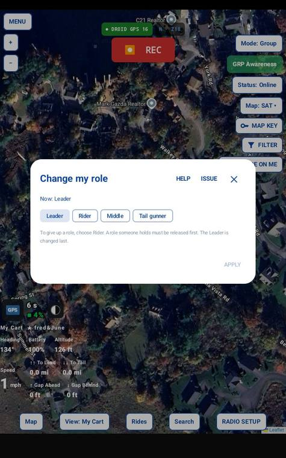

Change my role

Tap your new role.